# 1. Header and Contributions

# Analysis of Electric Car Company Finances

# Spring 2025 Data Science Project

# By Chukwuemeka Nsolo, Isatou Jawara, Ryan Selser, Spencer Zheng

Contributions:

Chukwuemeka Nsolo

B: Dataset Curation and Preprocessing: Organized the CSV datasets for car manufacturer financials into three dataframes: Balance Sheet, Cash Flow, and Income Statement, extracting the financial information I felt was most important for our project's purposes.

C: Data Exploration and Summary Statistics: Conducted ANOVA and Post-Hoc Tukey hypothesis tests to determine if there were significant statistical differences in the mean of liquidity for at least one car manufacturer.

G: Final Tutorial Report Creation: Helped in writing key parts of the tutorial's introduction, insights, and conclusion.

Isatou Jawara

A: Project idea: I came up the project idea, to analysis the financial standing of various elective vehicle car companies. The inspiration for this idea came from the current finance class I am talking about the business school. I wanted to cross apply new knowledge of data science with fiance

B: Dataset Curation and Preprocessing: I collected our datasets from two trusted sources: Mergentonline.com. (n.d.). https://www.mergentonline.com/ Morningstar | Empowering Investor Success. (n.d.-a). https://www.morningstar.com/ I collected the Balance sheet, Statement of Cash Flows and Income statement for each company over a 10 year span. Then we cleaned the data to represent 1 currency USD.

C,G: Data Exploration and Summary Statistics: Correlation testing between liquidity and goodwill created a chart with liquidity and goodwill as axes then show correlation

Spencer Zheng

B: I did the research for currency conversions then set up the code to implement it.

C: I created some of the summary statistics and the horizontal boxplots for revenue. I also conducted Kruskal-Wallis and Dunn's Tests to determine if there were statistical differences in the distribution of liquidity between companies, and created a frequency polygon graph to visualize these distributions.

G: I wrote comments on all the code except for the Machine Learning section. I also wrote commentary for the tutorial and did general formatting in order to help with the tutorial's readability and clarity.

Ryan Selser

C: Generated Plot for rolling revenue average over time and authored comments and conclusions surrounding the plot generated from this.

D, E: Designed and ran Linear Regression on the revenue over the years, and wrote analysis and conclusions under the visualization of this data, also generated the plots for this data.

G: Authored some of the commentary of the tutorial, such as the explanation of steps in the data cleaing section, the Machine Learning analysis section, and the general data visualization section.

# 2. Introduction

In this tutorial, we will walk you through a comprehensive financial analysis of leading automakers across data from balance sheets, cash flows, and income statements. By the end, you’ll understand how to import multiple CSVs, clean and merge them, convert currencies, compute key financial ratios, and apply both exploratory and inferential techniques (including machine learning models) to uncover trends and test hypotheses.

We will attempt to find trends and explore how different financial markers interact with one another, and how this can be used to predict future markers. Using machine learning, our goal is to predict an electric car company’s revenue using critical financial details as features. In areas such as stocks, predicting trends in a company’s financials is crucial in determining where and when to invest.

# 3. Data Curation

In order to store the data in appropriate data structures, we need pandas, which we will import as pd. For numerical operations with the data, we need numpy, which we will import as np. To visualize the data, we need matplotlib.pyplot, which we will import as plt, matplotlib.ticker, and seaborn, which we will import as sns. Most of the statistical tests we use are included under scipy, but we need Dunn's Post-Hoc Test from scikit_posthocs and Tukey's Pairwise HSD Test from statsmodels. scikit_posthocs is not included with Google Colab by default, so we add a command to install it via pip to make this file compatible with Google Colab. For machine learning, we import LinearRegression from sklearn.

```python
# We import all the above modules here
import pandas as pd
import numpy as np
import scipy
import matplotlib.pyplot as plt
import matplotlib.ticker
import seaborn as sns
%pip install scikit-posthocs
from scikit_posthocs import posthoc_dunn
from statsmodels.stats.multicomp import pairwise_tukeyhsd
from sklearn.linear_model import LinearRegression
from sklearn.model_selection import KFold, cross_val_score
from sklearn.ensemble import RandomForestRegressor
# We set pandas to show all rows of a Series or DataFrame when one is printed or displayed
pd.set_option('display.max_rows', None)
```

We collect our raw datasets from Mergent Online (https://www.mergentonline.com/). The data we have is for two EV-centered companies, BYD from China and Tesla from the US, and two legacy car companies, General Motors from the US and Volkswagen from Germany.

This data is split into Balance Sheets, Cash Flows, and Income Statements, as is standard practice for companies.

First, we will load the raw data from the csv files into pandas dataframes to manipulate the data. Dataframes are a data structure that allows a user to complete simple data manipulations using the various functions. Comprehensive documentation on pandas can be found here: https://pandas.pydata.org/docs/user_guide/basics.html

```python
# We load the data here
BYD_BS_df = pd.read_csv('BYD_BalanceSheet.csv')
GENERALM_BS_df = pd.read_csv('GENERALM_BalanceSheet.csv')
TESLA_BS_df = pd.read_csv('TESLA_BalanceSheet.csv')
VOLKSW_BS_df = pd.read_csv('VOLKSW_BalanceSheet.csv')

BYD_CF_df = pd.read_csv('BYD_CashFlow.csv')
GENERALM_CF_df = pd.read_csv('GENERALM_CashFlow.csv')
TESLA_CF_df = pd.read_csv('TESLA_CashFlow.csv')
VOLKSW_CF_df = pd.read_csv('VOLKSW_CashFlow.csv')


BYD_IS_df = pd.read_csv('BYD_IncomeStatement.csv')
GENERALM_IS_df = pd.read_csv('GENERALM_IncomeStatement.csv')
TESLA_IS_df = pd.read_csv('TESLA_IncomeStatement.csv')
VOLKSW_IS_df = pd.read_csv('VOLKSW_IncomeStatement.csv')
```

# Formatting the Data

Below, we will transform the Balance Sheets, Cash Flow, and Income Statement DataFrames by doing 4 key things:

-Load and reshape each raw CSV into a pandas DataFrame, then call organize(df) to transpose it, promote the first row to column headers, and reset the index.

-Tag every table with a new Car column (e.g. “BYD”, “General Motors”, etc.) so that we can tell them apart after merging.

-Unify key line items (Goodwill, Inventories, Total_Equity, Accounts_Payable, Comprehensive_Income) via .assign(), pulling from each company's original column names.

-Intersect and combine by keeping only the columns present in all four tables, concatenating them into one bs_df, and dropping any rows missing a Report Date.

**Balance Sheets**

```python
# We set up a helper function since the data is all formatted the same
def organize(df):
    # We make the dates rows instead of columns
    df = df.transpose()
    # We take the preexisting labels and make them our column names
    df.columns = df.iloc[0]
    # We drop the previous column
    df = df[1:]
    # We reset the index, making sure to drop the old index
    df = df.reset_index(drop=True)
    # We drop the axis names
    df = df.rename_axis(None, axis=1)
    return df

# We call organize on all the dataframes and insert the company name as a column for each
BYD_BS_df = organize(BYD_BS_df)
BYD_BS_df.insert(0, 'Car', 'BYD')
GENERALM_BS_df = organize(GENERALM_BS_df)
GENERALM_BS_df.insert(0, 'Car', 'General Motors')
TESLA_BS_df = organize(TESLA_BS_df)
TESLA_BS_df.insert(0, 'Car', 'Tesla')
VOLKSW_BS_df = organize(VOLKSW_BS_df)
VOLKSW_BS_df.insert(0, 'Car', 'Volkswagen')

# We rename the columns to standardize them
BYD_BS_df2 = BYD_BS_df.assign(Goodwill=BYD_BS_df['Goodwill'], Inventories=BYD_BS_df['Inventories'], Total_Equity=BYD_BS_df['Total equity'], Accounts_Payable=BYD_BS_df['Accounts payable'], Comprehensive_Income=BYD_BS_df['Other comprehensive income'])
GENERALM_BS_df2 = GENERALM_BS_df.assign(Goodwill=GENERALM_BS_df['Goodwill & intangible assets, net'], Total_Equity=GENERALM_BS_df['Total equity (deficit)'], Accounts_Payable=GENERALM_BS_df['Accounts payable (principally trade)'], Comprehensive_Income=GENERALM_BS_df['Accumulated other comprehensive income (loss)'])
TESLA_BS_df2 = TESLA_BS_df.assign(Goodwill=TESLA_BS_df['Goodwill'], Inventories=TESLA_BS_df['Inventory'], Total_Equity=TESLA_BS_df['Total Equity'], Accounts_Payable=TESLA_BS_df['Accounts payable'], Comprehensive_Income=TESLA_BS_df['Accumulated other comprehensive income (loss)'])
VOLKSW_BS_df2 = VOLKSW_BS_df.assign(Goodwill=VOLKSW_BS_df['Goodwill, net'], Inventories=VOLKSW_BS_df['Inventories'], Total_Equity=VOLKSW_BS_df['Total equity'], Accounts_Payable='', Comprehensive_Income='')

# We get the columns the dataframes have in common
bs_common = BYD_BS_df2.columns.intersection(GENERALM_BS_df2.columns)
bs_common = bs_common.intersection(TESLA_BS_df2.columns)
bs_common = bs_common.intersection(VOLKSW_BS_df2.columns)
# We concatenate the dataframes and drop any rows where the date is unreported, then display the merged dataframe
bs_df = pd.concat([BYD_BS_df2[bs_common], GENERALM_BS_df2[bs_common], TESLA_BS_df2[bs_common], VOLKSW_BS_df2[bs_common]])
bs_df.dropna(subset=['Report Date'], inplace=True)
bs_df
```

|  | Car | Report Date | Currency | Audit Status | Consolidated | Scale | Goodwill | Inventories | Cash & cash equivalents | Total current assets | Total assets | Total current liabilities | Total_Equity | Accounts_Payable | Comprehensive_Income |
| --- | --- | --- | --- | --- | --- | --- | --- | --- | --- | --- | --- | --- | --- | --- | --- |
| 0 | BYD | 12/31/2023 | CNY | Not Qualified | Yes | Billions | 4.428 | 87.677 | 109.094 | 302.121 | 679.548 | 453.667 | 150.462 | 194.43 | 0.604 |
| 2 | BYD | 12/31/2022 | CNY | Not Qualified | Yes | Billions | 0.066 | 79.107 | 51.471 | 240.804 | 493.861 | 333.345 | 121.39 | 140.437 | 0.428 |
| 4 | BYD | 12/31/2021 | CNY | Not Qualified | Yes | Billions | 0.066 | 43.355 | 50.457 | 166.11 | 295.78 | 171.304 | 104.244 | 73.16 | -0.124 |
| 6 | BYD | 12/31/2020 | CNY | Not Qualified | Yes | Billions | 0.066 | 31.396 | 14.445 | 111.605 | 201.017 | 106.431 | 64.454 | 42.983 | -0.556 |
| 8 | BYD | 12/31/2019 | CNY | Not Qualified | Yes | Billions | 0.066 | 25.572 | 12.65 | 106.967 | 195.642 | 108.029 | 62.601 | 22.521 | -0.047 |
| 10 | BYD | 12/31/2018 | CNY | Not Qualified | Yes | Billions | 0.066 | 26.33 | 13.052 | 115.211 | 194.571 | 116.569 | 60.694 | 25.142 | -0.291 |
| 12 | BYD | 12/31/2017 | CNY | Not Qualified | Yes | Billions | 0.066 | 19.873 | 9.903 | 102.684 | 178.099 | 104.997 | 59.957 | 23.32 | 1.26 |
| 14 | BYD | 12/31/2016 | CNY | Not Qualified | Yes | Billions | 0.066 | 17.378 | 7.111 | 78.354 | 145.071 | 78.318 | 55.409 | - | - |
| 16 | BYD | 12/31/2015 | CNY | Not Qualified | Yes | Billions | 0.066 | 15.751 | 6.011 | 54.519 | 115.486 | 66.11 | 36.029 | - | - |
| 18 | BYD | 12/31/2014 | CNY | Not Qualified | Yes | Billions | 0.066 | 9.978 | 3.95 | 40.834 | 94.009 | 53.022 | 28.894 | - | - |
| 0 | General Motors | 12/31/2024 | USD | Not Qualified | Yes | Billions | 4.551 | 14.564 | 19.872 | 108.545 | 279.761 | 96.265 | 65.59 | 25.68 | - |
| 2 | General Motors | 12/31/2023 | USD | Not Qualified | Yes | Billions | 4.862 | 16.461 | 18.853 | 101.618 | 273.064 | 94.445 | 68.189 | 28.114 | -10.247 |
| 4 | General Motors | 12/31/2022 | USD | Not Qualified | Yes | Billions | 4.945 | 15.366 | 19.153 | 100.451 | 264.037 | 91.173 | 71.927 | 27.486 | -7.901 |
| 6 | General Motors | 12/31/2021 | USD | Not Qualified | Yes | Billions | 5.087 | 12.988 | 20.067 | 82.103 | 244.718 | 74.408 | 65.815 | 20.391 | -9.269 |
| 8 | General Motors | 12/31/2020 | USD | Not Qualified | Yes | Billions | 5.23 | 10.235 | 19.992 | 80.924 | 235.194 | 79.91 | 49.677 | 19.928 | -13.488 |
| 10 | General Motors | 12/31/2019 | USD | Not Qualified | Yes | Billions | 5.337 | 10.398 | 19.069 | 74.992 | 228.037 | 84.905 | 45.957 | 21.018 | -11.156 |
| 12 | General Motors | 12/31/2018 | USD | Not Qualified | Yes | Billions | 5.579 | 9.816 | 20.844 | 75.293 | 227.339 | 82.237 | 42.777 | 22.297 | -9.039 |
| 14 | General Motors | 12/31/2017 | USD | Not Qualified | Yes | Billions | 5.849 | 10.663 | 15.512 | 68.744 | 212.482 | 76.89 | 36.2 | 23.929 | -8.011 |
| 16 | General Motors | 12/31/2016 | USD | Not Qualified | Yes | Billions | 6.259 | 13.788 | 12.96 | 76.203 | 221.69 | 85.181 | 44.075 | 26.961 | -9.33 |
| 18 | General Motors | 12/31/2015 | USD | Not Qualified | Yes | Billions | 5.947 | 13.764 | 15.238 | 78.007 | 194.52 | 71.466 | 40.323 | 24.062 | -8.036 |
| 0 | Tesla | 12/31/2024 | USD | Not Qualified | Yes | Billions | 0.244 | 12.017 | 16.139 | 58.36 | 122.07 | 28.821 | 73.617 | 12.474 | -0.67 |
| 2 | Tesla | 12/31/2023 | USD | Not Qualified | Yes | Billions | 0.253 | 13.626 | 16.398 | 49.616 | 106.618 | 28.748 | 63.367 | 14.431 | -0.143 |
| 4 | Tesla | 12/31/2022 | USD | Not Qualified | Yes | Billions | 0.194 | 12.839 | 16.253 | 40.917 | 82.338 | 26.709 | - | 15.255 | -0.361 |
| 6 | Tesla | 12/31/2021 | USD | Not Qualified | Yes | Billions | 0.2 | 5.757 | 17.576 | 27.1 | 62.131 | 19.705 | - | 10.025 | 0.054 |
| 8 | Tesla | 12/31/2020 | USD | Not Qualified | Yes | Billions | 0.207 | 4.101 | 19.384 | 26.717 | 52.148 | 14.248 | - | 6.051 | 0.363 |
| 10 | Tesla | 12/31/2019 | USD | Not Qualified | Yes | Billions | 0.198 | 3.552 | 6.268 | 12.103 | 34.309 | 10.667 | - | 3.771 | -0.036 |
| 12 | Tesla | 12/31/2018 | USD | Not Qualified | Yes | Billions | 0.068 | 3.113 | 3.686 | 8.306 | 29.74 | 9.992 | - | 3.404 | -0.008 |
| 14 | Tesla | 12/31/2017 | USD | Not Qualified | Yes | Billions | 0.06 | 2.264 | 3.368 | 6.571 | 28.655 | 7.675 | - | 2.39 | 0.033 |
| 16 | Tesla | 12/31/2016 | USD | Not Qualified | Yes | Billions | - | 2.067 | 3.393 | 6.26 | 22.664 | 5.827 | - | 1.86 | -0.024 |
| 18 | Tesla | 12/31/2015 | USD | Not Qualified | Yes | Billions | - | 1.278 | 1.197 | 2.792 | 8.092 | 2.816 | - | 0.916 | -0.004 |
| 0 | Volkswagen | 12/31/2023 | EUR | Not Qualified | Yes | Billions | 26.292 | 53.601 | 43.449 | 239.644 | 600.338 | 205.874 | 189.912 |  |  |
| 2 | Volkswagen | 12/31/2022 | EUR | Not Qualified | Yes | Billions | 26.202 | 52.274 | 29.172 | 224.309 | 564.772 | 182.992 | 178.327 |  |  |
| 4 | Volkswagen | 12/31/2021 | EUR | Not Qualified | Yes | Billions | 26.174 | 43.725 | 39.723 | 200.347 | 528.609 | 164.393 | 146.154 |  |  |
| 6 | Volkswagen | 12/31/2020 | EUR | Not Qualified | Yes | Billions | 23.318 | 43.823 | 33.909 | 194.944 | 497.114 | 165.41 | 128.783 |  |  |
| 8 | Volkswagen | 12/31/2019 | EUR | Not Qualified | Yes | Billions | 23.247 | 46.742 | 25.923 | 187.463 | 488.071 | 167.924 | 123.651 |  |  |
| 10 | Volkswagen | 12/31/2018 | EUR | Not Qualified | Yes | Billions | 23.317 | 45.745 | 28.938 | 183.536 | 458.156 | 167.968 | 117.342 |  |  |
| 12 | Volkswagen | 12/31/2017 | EUR | Not Qualified | Yes | Billions | 23.442 | 40.415 | 18.457 | 160.112 | 422.193 | 160.389 | 109.077 |  |  |
| 14 | Volkswagen | 12/31/2016 | EUR | Not Qualified | Yes | Billions | 23.558 | 38.978 | 19.265 | 155.722 | 409.732 | 177.515 | 92.91 |  |  |
| 16 | Volkswagen | 12/31/2015 | EUR | Not Qualified | Yes | Billions | 23.646 | 35.048 | 20.871 | 145.387 | 381.935 | 148.489 | 88.27 |  |  |
| 18 | Volkswagen | 12/31/2014 | EUR | Not Qualified | Yes | Billions | 23.577 | 31.466 | 19.123 | 131.102 | 351.209 | 130.706 | 90.189 |  |  |

**Cash Flow Statements**

```python
# We call organize on all the dataframes and insert the company name as a column for each

BYD_CF_df = organize(BYD_CF_df)
BYD_CF_df.insert(0, 'Car', 'BYD')
GENERALM_CF_df = organize(GENERALM_CF_df)
GENERALM_CF_df.insert(0, 'Car', 'General Motors')
TESLA_CF_df = organize(TESLA_CF_df)
TESLA_CF_df.insert(0, 'Car', 'Tesla')
VOLKSW_CF_df = organize(VOLKSW_CF_df)
VOLKSW_CF_df.insert(0, 'Car', 'Volkswagen')

# We rename the columns to standardize them
BYD_CF_df2 = BYD_CF_df.assign(Inventory=BYD_CF_df['Decrease (increase) in inventories'], CF_From_Operating_Activities=BYD_CF_df['Net cash flows from operating activities'], CF_From_Investing_Activities=BYD_CF_df['Net cash flows from (used in) investing activities'],
                             CF_From_Financing_Activities=BYD_CF_df['Net cash flows from (used in) financing activities'], Dividends_Paid=BYD_CF_df['Cash paid for dividends, profit distribution & interest'])
GENERALM_CF_df2 = GENERALM_CF_df.assign(Inventory=GENERALM_CF_df['Inventories'], CF_From_Operating_Activities=GENERALM_CF_df['Net cash flows from operating activities'], CF_From_Investing_Activities=GENERALM_CF_df['Net cash flows from (used in) investing activities'],
                                       CF_From_Financing_Activities=GENERALM_CF_df['Net cash flows from (used in) financing activities'], Dividends_Paid=GENERALM_CF_df['Dividends paid'])
TESLA_CF_df2 = TESLA_CF_df.assign(Inventory=TESLA_CF_df['Inventory'], CF_From_Operating_Activities=TESLA_CF_df['Net cash flows from operating activities'], CF_From_Investing_Activities=TESLA_CF_df['Net cash (used in) flows from investing activities'],
                                 CF_From_Financing_Activities=TESLA_CF_df['Net cash flows from financing activities'], Dividends_Paid='')
VOLKSW_CF_df2 = VOLKSW_CF_df.assign(Inventory=VOLKSW_CF_df['Change in inventories'], CF_From_Operating_Activities=VOLKSW_CF_df['Cash flows from operating activities'], CF_From_Investing_Activities=VOLKSW_CF_df['Cash flows from (used in) investing activities'],
                                   CF_From_Financing_Activities=VOLKSW_CF_df['Cash flows from (used in) financing activities'], Dividends_Paid=VOLKSW_CF_df['Dividends paid'])

# We get the columns the dataframes have in common
cf_common = BYD_CF_df2.columns.intersection(GENERALM_CF_df2.columns)
cf_common = cf_common.intersection(TESLA_CF_df2.columns)
cf_common = cf_common.intersection(VOLKSW_CF_df2.columns)
# We concatenate the dataframes and drop any rows where the date is unreported, then display the merged dataframe
cf_df = pd.concat([BYD_CF_df2[cf_common], GENERALM_CF_df2[cf_common], TESLA_CF_df2[cf_common], VOLKSW_CF_df2[cf_common]])
cf_df.dropna(subset=['Report Date'], inplace=True)
cf_df
```

|  | Car | Report Date | Currency | Audit Status | Consolidated | Scale | Inventory | CF_From_Operating_Activities | CF_From_Investing_Activities | CF_From_Financing_Activities | Dividends_Paid |
| --- | --- | --- | --- | --- | --- | --- | --- | --- | --- | --- | --- |
| 0 | BYD | 12/31/2023 | CNY | Not Qualified | Yes | Billions | -7.602 | 169.725 | -125.664 | 12.817 | 0.028 |
| 2 | BYD | 12/31/2022 | CNY | Not Qualified | Yes | Billions | -36.565 | 140.838 | -120.596 | -19.489 | -1.633 |
| 4 | BYD | 12/31/2021 | CNY | Not Qualified | Yes | Billions | -12.893 | 65.467 | -45.404 | 16.063 | -2.619 |
| 6 | BYD | 12/31/2020 | CNY | Not Qualified | Yes | Billions | -6.702 | 45.393 | -14.444 | -28.907 | -3.686 |
| 8 | BYD | 12/31/2019 | CNY | Not Qualified | Yes | Billions | 0.284 | 14.741 | -20.881 | 6.61 | -4.389 |
| 10 | BYD | 12/31/2018 | CNY | Not Qualified | Yes | Billions | -6.585 | 12.523 | -14.231 | 3.917 | -4.12 |
| 12 | BYD | 12/31/2017 | CNY | Not Qualified | Yes | Billions | -2.727 | 6.368 | -15.964 | 11.168 | -3.201 |
| 14 | BYD | 12/31/2016 | CNY | Not Qualified | Yes | Billions | -1.985 | -1.846 | -13.421 | 16.27 | - |
| 16 | BYD | 12/31/2015 | CNY | Not Qualified | Yes | Billions | -6.224 | 3.842 | -10.736 | 8.75 | -0.037 |
| 18 | BYD | 12/31/2014 | CNY | Not Qualified | Yes | Billions | -1.918 | 0.038 | -7.901 | 7.271 | -0.124 |
| 0 | General Motors | 12/31/2024 | USD | Not Qualified | Yes | Billions | 0.666 | 20.129 | -20.517 | 1.938 | -0.653 |
| 2 | General Motors | 12/31/2023 | USD | Not Qualified | Yes | Billions | -0.757 | 20.93 | -14.663 | -6.353 | -0.597 |
| 4 | General Motors | 12/31/2022 | USD | Not Qualified | Yes | Billions | -2.581 | 16.043 | -17.882 | 0.383 | -0.397 |
| 6 | General Motors | 12/31/2021 | USD | Not Qualified | Yes | Billions | -3.155 | 15.188 | -16.355 | 1.744 | -0.186 |
| 8 | General Motors | 12/31/2020 | USD | Not Qualified | Yes | Billions | -0.104 | 16.67 | -21.826 | 5.552 | -0.669 |
| 10 | General Motors | 12/31/2019 | USD | Not Qualified | Yes | Billions | -0.761 | 15.021 | -10.899 | -4.677 | -2.35 |
| 12 | General Motors | 12/31/2018 | USD | Not Qualified | Yes | Billions | 0.399 | 15.256 | -20.763 | 11.454 | -2.242 |
| 14 | General Motors | 12/31/2017 | USD | Not Qualified | Yes | Billions | 0.44 | 17.328 | -27.572 | 12.584 | -2.233 |
| 16 | General Motors | 12/31/2016 | USD | Not Qualified | Yes | Billions | -0.32 | - | -35.643 | 17.139 | -2.368 |
| 18 | General Motors | 12/31/2015 | USD | Not Qualified | Yes | Billions | -1.35 | - | -28.035 | 13.686 | -2.242 |
| 0 | Tesla | 12/31/2024 | USD | Not Qualified | Yes | Billions | 0.937 | 14.923 | -18.787 | 3.853 |  |
| 2 | Tesla | 12/31/2023 | USD | Not Qualified | Yes | Billions | -1.195 | 13.256 | -15.584 | 2.589 |  |
| 4 | Tesla | 12/31/2022 | USD | Not Qualified | Yes | Billions | -6.465 | 14.724 | -11.973 | -3.527 |  |
| 6 | Tesla | 12/31/2021 | USD | Not Qualified | Yes | Billions | -1.709 | 11.497 | -7.868 | -5.203 |  |
| 8 | Tesla | 12/31/2020 | USD | Not Qualified | Yes | Billions | -0.422 | 5.943 | -3.132 | 9.973 |  |
| 10 | Tesla | 12/31/2019 | USD | Not Qualified | Yes | Billions | -0.429 | 2.405 | -1.436 | 1.529 |  |
| 12 | Tesla | 12/31/2018 | USD | Not Qualified | Yes | Billions | -1.023 | 2.098 | -2.337 | 0.574 |  |
| 14 | Tesla | 12/31/2017 | USD | Not Qualified | Yes | Billions | -0.179 | -0.061 | -4.419 | 4.415 |  |
| 16 | Tesla | 12/31/2016 | USD | Not Qualified | Yes | Billions | - | -0.124 | -1.416 | 3.744 |  |
| 18 | Tesla | 12/31/2015 | USD | Not Qualified | Yes | Billions | - | -0.524 | -1.674 | 1.524 |  |
| 0 | Volkswagen | 12/31/2023 | EUR | Not Qualified | Yes | Billions | -2.071 | 19.356 | -19.812 | 16.008 | -11.732 |
| 2 | Volkswagen | 12/31/2022 | EUR | Not Qualified | Yes | Billions | -8.385 | 28.496 | -41.822 | 4.225 | -4.362 |
| 4 | Volkswagen | 12/31/2021 | EUR | Not Qualified | Yes | Billions | 2.11 | 38.633 | -26.128 | -7.754 | -3.022 |
| 6 | Volkswagen | 12/31/2020 | EUR | Not Qualified | Yes | Billions | 1.334 | 24.901 | -22.69 | 7.637 | -2.952 |
| 8 | Volkswagen | 12/31/2019 | EUR | Not Qualified | Yes | Billions | -0.674 | 17.983 | -21.146 | -0.865 | -2.899 |
| 10 | Volkswagen | 12/31/2018 | EUR | Not Qualified | Yes | Billions | -5.372 | 7.272 | -21.59 | 24.566 | -2.375 |
| 12 | Volkswagen | 12/31/2017 | EUR | Not Qualified | Yes | Billions | -4.198 | -1.185 | -16.508 | 17.625 | -1.332 |
| 14 | Volkswagen | 12/31/2016 | EUR | Not Qualified | Yes | Billions | -3.637 | 9.43 | -20.679 | 9.712 | -0.364 |
| 16 | Volkswagen | 12/31/2015 | EUR | Not Qualified | Yes | Billions | -3.149 | 13.679 | -21.151 | 9.068 | -2.516 |
| 18 | Volkswagen | 12/31/2014 | EUR | Not Qualified | Yes | Billions | -2.214 | 10.784 | -19.099 | 4.645 | -1.962 |

**Income Statement**

```python
# We call organize on all the dataframes and insert the company name as a column for each
BYD_IS_df = organize(BYD_IS_df)
BYD_IS_df.insert(0, 'Car', 'BYD')
GENERALM_IS_df = organize(GENERALM_IS_df)
GENERALM_IS_df.insert(0, 'Car', 'General Motors')
TESLA_IS_df = organize(TESLA_IS_df)
TESLA_IS_df.insert(0, 'Car', 'Tesla')
VOLKSW_IS_df = organize(VOLKSW_IS_df)
VOLKSW_IS_df.insert(0, 'Car', 'Volkswagen')

# We rename the columns to standardize them
BYD_IS_df2 = BYD_IS_df.assign(Revenue=BYD_IS_df['Operating revenues'], Income_Tax_Expense=BYD_IS_df['Income tax expense'], Total_Full_Time_Employees=BYD_IS_df['Full-Time Employees (Period End)'], Deferred_Tax_Expense='')
GENERALM_IS_df2 = GENERALM_IS_df.assign(Revenue=GENERALM_IS_df['Total net sales & revenue'], Income_Tax_Expense=GENERALM_IS_df['Income tax expense (benefit)'], Total_Full_Time_Employees=GENERALM_IS_df['Number of full time employees'], Deferred_Tax_Expense=GENERALM_IS_df['Total deferred income tax expense (benefit)'])
TESLA_IS_df2 = TESLA_IS_df.assign(Revenue=TESLA_IS_df['Total revenues'], Income_Tax_Expense=TESLA_IS_df['Current income taxes (benefit)'], Total_Full_Time_Employees=TESLA_IS_df['Number of full time employees'], Deferred_Tax_Expense=TESLA_IS_df['Deferred income taxes (benefit)'])
VOLKSW_IS_df2 = VOLKSW_IS_df.assign(Revenue=VOLKSW_IS_df['Sales revenue'], Income_Tax_Expense=VOLKSW_IS_df['Income tax income or expense'], Total_Full_Time_Employees=VOLKSW_IS_df['Number of full time employees'], Deferred_Tax_Expense=VOLKSW_IS_df['Deferred income tax'])

# We get the columns the dataframes have in common
is_common = BYD_IS_df2.columns.intersection(GENERALM_IS_df2.columns)
is_common = is_common.intersection(TESLA_IS_df2.columns)
is_common = is_common.intersection(VOLKSW_IS_df2.columns)
# We merge the dataframes and drop any rows where the date is unreported, then display the merged dataframe
is_df = pd.concat([BYD_IS_df2[is_common], GENERALM_IS_df2[is_common], TESLA_IS_df2[is_common], VOLKSW_IS_df2[is_common]])
is_df.dropna(subset=['Report Date'], inplace=True)
is_df
```

|  | Car | Report Date | Currency | Audit Status | Consolidated | Scale | Revenue | Total number of employees | Income_Tax_Expense | Total_Full_Time_Employees | Deferred_Tax_Expense |
| --- | --- | --- | --- | --- | --- | --- | --- | --- | --- | --- | --- |
| 0 | BYD | 12/31/2023 | CNY | Not Qualified | Yes | Billions | 602.315 | 703504 | -5.925 | 703504 |  |
| 2 | BYD | 12/31/2022 | CNY | Not Qualified | Yes | Billions | 424.061 | - | -3.367 | - |  |
| 4 | BYD | 12/31/2021 | CNY | Not Qualified | Yes | Billions | 216.142 | - | -0.551 | - |  |
| 6 | BYD | 12/31/2020 | CNY | Not Qualified | Yes | Billions | 156.598 | - | -0.869 | - |  |
| 8 | BYD | 12/31/2019 | CNY | Not Qualified | Yes | Billions | 127.739 | - | -0.312 | - |  |
| 10 | BYD | 12/31/2018 | CNY | Not Qualified | Yes | Billions | 130.055 | - | -0.829 | - |  |
| 12 | BYD | 12/31/2017 | CNY | Not Qualified | Yes | Billions | 105.915 | - | -0.704 | - |  |
| 14 | BYD | 12/31/2016 | CNY | Not Qualified | Yes | Billions | 100.208 | 194000 | -1.088 | - |  |
| 16 | BYD | 12/31/2015 | CNY | Not Qualified | Yes | Billions | 77.612 | 200000 | -0.657 | - |  |
| 18 | BYD | 12/31/2014 | CNY | Not Qualified | Yes | Billions | 55.366 | 190000 | -0.134 | - |  |
| 0 | General Motors | 12/31/2024 | USD | Not Qualified | Yes | Billions | 187.442 | 162000 | 2.556 | 162000 | 1.368 |
| 2 | General Motors | 12/31/2023 | USD | Not Qualified | Yes | Billions | 171.842 | 163000 | 0.563 | 76000 | -1.041 |
| 4 | General Motors | 12/31/2022 | USD | Not Qualified | Yes | Billions | 156.735 | 167000 | 1.888 | 81000 | 0.425 |
| 6 | General Motors | 12/31/2021 | USD | Not Qualified | Yes | Billions | 127.004 | 157000 | 2.771 | 74000 | 2.214 |
| 8 | General Motors | 12/31/2020 | USD | Not Qualified | Yes | Billions | 122.485 | 155000 | 1.774 | - | 0.925 |
| 10 | General Motors | 12/31/2019 | USD | Not Qualified | Yes | Billions | 137.237 | 164000 | 0.769 | - | -0.133 |
| 12 | General Motors | 12/31/2018 | USD | Not Qualified | Yes | Billions | 147.049 | 173000 | 0.474 | - | -0.112 |
| 14 | General Motors | 12/31/2017 | USD | Not Qualified | Yes | Billions | 145.588 | 180000 | 11.533 | - | 10.88 |
| 16 | General Motors | 12/31/2016 | USD | Not Qualified | Yes | Billions | 166.38 | 225000 | 2.416 | - | 1.886 |
| 18 | General Motors | 12/31/2015 | USD | Not Qualified | Yes | Billions | 152.356 | 215000 | -1.897 | - | -2.757 |
| 0 | Tesla | 12/31/2024 | USD | Not Qualified | Yes | Billions | 97.69 | 125665 | 1.36 | 125665 | 0.477 |
| 2 | Tesla | 12/31/2023 | USD | Not Qualified | Yes | Billions | 96.773 | 140473 | 1.348 | 140473 | -6.349 |
| 4 | Tesla | 12/31/2022 | USD | Not Qualified | Yes | Billions | 81.462 | - | 1.328 | 127855 | -0.196 |
| 6 | Tesla | 12/31/2021 | USD | Not Qualified | Yes | Billions | 53.823 | - | 0.848 | 99290 | -0.149 |
| 8 | Tesla | 12/31/2020 | USD | Not Qualified | Yes | Billions | 31.536 | - | 0.252 | 70757 | 0.04 |
| 10 | Tesla | 12/31/2019 | USD | Not Qualified | Yes | Billions | 24.578 | - | 0.091 | 48016 | 0.019 |
| 12 | Tesla | 12/31/2018 | USD | Not Qualified | Yes | Billions | 21.461 | - | 0.026 | 48817 | 0.032 |
| 14 | Tesla | 12/31/2017 | USD | Not Qualified | Yes | Billions | 11.759 | - | 0.035 | 37543 | -0.004 |
| 16 | Tesla | 12/31/2016 | USD | Not Qualified | Yes | Billions | 7 | - | 0.055 | 30025 | -0.028 |
| 18 | Tesla | 12/31/2015 | USD | Not Qualified | Yes | Billions | 4.046 | - | 0.011 | 13058 | 0.002 |
| 0 | Volkswagen | 12/31/2023 | EUR | Not Qualified | Yes | Billions | 322.284 | 684025 | -5.266 | 684025 | - |
| 2 | Volkswagen | 12/31/2022 | EUR | Not Qualified | Yes | Billions | 279.232 | - | -6.208 | 675805 | -0.946 |
| 4 | Volkswagen | 12/31/2021 | EUR | Not Qualified | Yes | Billions | 250.2 | - | -4.698 | 672800 | -0.086 |
| 6 | Volkswagen | 12/31/2020 | EUR | Not Qualified | Yes | Billions | 222.884 | - | -2.843 | 662600 | 0.307 |
| 8 | Volkswagen | 12/31/2019 | EUR | Not Qualified | Yes | Billions | 252.632 | - | -4.326 | 671200 | -0.18 |
| 10 | Volkswagen | 12/31/2018 | EUR | Not Qualified | Yes | Billions | 235.849 | - | -3.489 | 664496 | 0.043 |
| 12 | Volkswagen | 12/31/2017 | EUR | Not Qualified | Yes | Billions | 230.682 | - | -2.275 | 642292 | 0.93 |
| 14 | Volkswagen | 12/31/2016 | EUR | Not Qualified | Yes | Billions | 217.267 | - | -1.912 | 626715 | 1.361 |
| 16 | Volkswagen | 12/31/2015 | EUR | Not Qualified | Yes | Billions | 213.292 | - | -0.059 | 610076 | 2.8 |
| 18 | Volkswagen | 12/31/2014 | EUR | Not Qualified | Yes | Billions | 202.458 | - | -3.726 | 592586 | -0.094 |

# Merging and Cleaning

During this next step, we will take the data that was loaded in before and transform it to mkae it easier to work with. We will attempt to remove any inconsistencies within the data that would skew final results in one direction or the other, and we will reformat the data to make it easy to read and operate on. The process of data cleaning is an important one as it ensures that results gleaned form tests on the data set are accurate.

We first drop any leftover row indices in each statement DataFrame so that concatenations are clean. Then we perform two successive inner merges on the shared keys (Car, Report Date, Currency, Audit Status, Consolidated, and Scale) to produce one wide main_df containing the features from the balance statements, cash flows, and income statements.

```python
# We reset the indices of all three dataframes and drop the old indices so they don't become new columns
bs_df = bs_df.reset_index(drop=True)
cf_df = cf_df.reset_index(drop=True)
is_df = is_df.reset_index(drop=True)
# We merge all three dataframes on the columns they all have in common, ensuring no duplication.
main_df = bs_df.merge(cf_df, on=['Car', 'Report Date', 'Currency', 'Audit Status', 'Consolidated', 'Scale'])
main_df = main_df.merge(is_df, on=['Car', 'Report Date', 'Currency', 'Audit Status', 'Consolidated', 'Scale'])
main_df
```

|  | Car | Report Date | Currency | Audit Status | Consolidated | Scale | Goodwill | Inventories | Cash & cash equivalents | Total current assets | ... | Inventory | CF_From_Operating_Activities | CF_From_Investing_Activities | CF_From_Financing_Activities | Dividends_Paid | Revenue | Total number of employees | Income_Tax_Expense | Total_Full_Time_Employees | Deferred_Tax_Expense |
| --- | --- | --- | --- | --- | --- | --- | --- | --- | --- | --- | --- | --- | --- | --- | --- | --- | --- | --- | --- | --- | --- |
| 0 | BYD | 12/31/2023 | CNY | Not Qualified | Yes | Billions | 4.428 | 87.677 | 109.094 | 302.121 | ... | -7.602 | 169.725 | -125.664 | 12.817 | 0.028 | 602.315 | 703504 | -5.925 | 703504 |  |
| 1 | BYD | 12/31/2022 | CNY | Not Qualified | Yes | Billions | 0.066 | 79.107 | 51.471 | 240.804 | ... | -36.565 | 140.838 | -120.596 | -19.489 | -1.633 | 424.061 | - | -3.367 | - |  |
| 2 | BYD | 12/31/2021 | CNY | Not Qualified | Yes | Billions | 0.066 | 43.355 | 50.457 | 166.11 | ... | -12.893 | 65.467 | -45.404 | 16.063 | -2.619 | 216.142 | - | -0.551 | - |  |
| 3 | BYD | 12/31/2020 | CNY | Not Qualified | Yes | Billions | 0.066 | 31.396 | 14.445 | 111.605 | ... | -6.702 | 45.393 | -14.444 | -28.907 | -3.686 | 156.598 | - | -0.869 | - |  |
| 4 | BYD | 12/31/2019 | CNY | Not Qualified | Yes | Billions | 0.066 | 25.572 | 12.65 | 106.967 | ... | 0.284 | 14.741 | -20.881 | 6.61 | -4.389 | 127.739 | - | -0.312 | - |  |
| 5 | BYD | 12/31/2018 | CNY | Not Qualified | Yes | Billions | 0.066 | 26.33 | 13.052 | 115.211 | ... | -6.585 | 12.523 | -14.231 | 3.917 | -4.12 | 130.055 | - | -0.829 | - |  |
| 6 | BYD | 12/31/2017 | CNY | Not Qualified | Yes | Billions | 0.066 | 19.873 | 9.903 | 102.684 | ... | -2.727 | 6.368 | -15.964 | 11.168 | -3.201 | 105.915 | - | -0.704 | - |  |
| 7 | BYD | 12/31/2016 | CNY | Not Qualified | Yes | Billions | 0.066 | 17.378 | 7.111 | 78.354 | ... | -1.985 | -1.846 | -13.421 | 16.27 | - | 100.208 | 194000 | -1.088 | - |  |
| 8 | BYD | 12/31/2015 | CNY | Not Qualified | Yes | Billions | 0.066 | 15.751 | 6.011 | 54.519 | ... | -6.224 | 3.842 | -10.736 | 8.75 | -0.037 | 77.612 | 200000 | -0.657 | - |  |
| 9 | BYD | 12/31/2014 | CNY | Not Qualified | Yes | Billions | 0.066 | 9.978 | 3.95 | 40.834 | ... | -1.918 | 0.038 | -7.901 | 7.271 | -0.124 | 55.366 | 190000 | -0.134 | - |  |
| 10 | General Motors | 12/31/2024 | USD | Not Qualified | Yes | Billions | 4.551 | 14.564 | 19.872 | 108.545 | ... | 0.666 | 20.129 | -20.517 | 1.938 | -0.653 | 187.442 | 162000 | 2.556 | 162000 | 1.368 |
| 11 | General Motors | 12/31/2023 | USD | Not Qualified | Yes | Billions | 4.862 | 16.461 | 18.853 | 101.618 | ... | -0.757 | 20.93 | -14.663 | -6.353 | -0.597 | 171.842 | 163000 | 0.563 | 76000 | -1.041 |
| 12 | General Motors | 12/31/2022 | USD | Not Qualified | Yes | Billions | 4.945 | 15.366 | 19.153 | 100.451 | ... | -2.581 | 16.043 | -17.882 | 0.383 | -0.397 | 156.735 | 167000 | 1.888 | 81000 | 0.425 |
| 13 | General Motors | 12/31/2021 | USD | Not Qualified | Yes | Billions | 5.087 | 12.988 | 20.067 | 82.103 | ... | -3.155 | 15.188 | -16.355 | 1.744 | -0.186 | 127.004 | 157000 | 2.771 | 74000 | 2.214 |
| 14 | General Motors | 12/31/2020 | USD | Not Qualified | Yes | Billions | 5.23 | 10.235 | 19.992 | 80.924 | ... | -0.104 | 16.67 | -21.826 | 5.552 | -0.669 | 122.485 | 155000 | 1.774 | - | 0.925 |
| 15 | General Motors | 12/31/2019 | USD | Not Qualified | Yes | Billions | 5.337 | 10.398 | 19.069 | 74.992 | ... | -0.761 | 15.021 | -10.899 | -4.677 | -2.35 | 137.237 | 164000 | 0.769 | - | -0.133 |
| 16 | General Motors | 12/31/2018 | USD | Not Qualified | Yes | Billions | 5.579 | 9.816 | 20.844 | 75.293 | ... | 0.399 | 15.256 | -20.763 | 11.454 | -2.242 | 147.049 | 173000 | 0.474 | - | -0.112 |
| 17 | General Motors | 12/31/2017 | USD | Not Qualified | Yes | Billions | 5.849 | 10.663 | 15.512 | 68.744 | ... | 0.44 | 17.328 | -27.572 | 12.584 | -2.233 | 145.588 | 180000 | 11.533 | - | 10.88 |
| 18 | General Motors | 12/31/2016 | USD | Not Qualified | Yes | Billions | 6.259 | 13.788 | 12.96 | 76.203 | ... | -0.32 | - | -35.643 | 17.139 | -2.368 | 166.38 | 225000 | 2.416 | - | 1.886 |
| 19 | General Motors | 12/31/2015 | USD | Not Qualified | Yes | Billions | 5.947 | 13.764 | 15.238 | 78.007 | ... | -1.35 | - | -28.035 | 13.686 | -2.242 | 152.356 | 215000 | -1.897 | - | -2.757 |
| 20 | Tesla | 12/31/2024 | USD | Not Qualified | Yes | Billions | 0.244 | 12.017 | 16.139 | 58.36 | ... | 0.937 | 14.923 | -18.787 | 3.853 |  | 97.69 | 125665 | 1.36 | 125665 | 0.477 |
| 21 | Tesla | 12/31/2023 | USD | Not Qualified | Yes | Billions | 0.253 | 13.626 | 16.398 | 49.616 | ... | -1.195 | 13.256 | -15.584 | 2.589 |  | 96.773 | 140473 | 1.348 | 140473 | -6.349 |
| 22 | Tesla | 12/31/2022 | USD | Not Qualified | Yes | Billions | 0.194 | 12.839 | 16.253 | 40.917 | ... | -6.465 | 14.724 | -11.973 | -3.527 |  | 81.462 | - | 1.328 | 127855 | -0.196 |
| 23 | Tesla | 12/31/2021 | USD | Not Qualified | Yes | Billions | 0.2 | 5.757 | 17.576 | 27.1 | ... | -1.709 | 11.497 | -7.868 | -5.203 |  | 53.823 | - | 0.848 | 99290 | -0.149 |
| 24 | Tesla | 12/31/2020 | USD | Not Qualified | Yes | Billions | 0.207 | 4.101 | 19.384 | 26.717 | ... | -0.422 | 5.943 | -3.132 | 9.973 |  | 31.536 | - | 0.252 | 70757 | 0.04 |
| 25 | Tesla | 12/31/2019 | USD | Not Qualified | Yes | Billions | 0.198 | 3.552 | 6.268 | 12.103 | ... | -0.429 | 2.405 | -1.436 | 1.529 |  | 24.578 | - | 0.091 | 48016 | 0.019 |
| 26 | Tesla | 12/31/2018 | USD | Not Qualified | Yes | Billions | 0.068 | 3.113 | 3.686 | 8.306 | ... | -1.023 | 2.098 | -2.337 | 0.574 |  | 21.461 | - | 0.026 | 48817 | 0.032 |
| 27 | Tesla | 12/31/2017 | USD | Not Qualified | Yes | Billions | 0.06 | 2.264 | 3.368 | 6.571 | ... | -0.179 | -0.061 | -4.419 | 4.415 |  | 11.759 | - | 0.035 | 37543 | -0.004 |
| 28 | Tesla | 12/31/2016 | USD | Not Qualified | Yes | Billions | - | 2.067 | 3.393 | 6.26 | ... | - | -0.124 | -1.416 | 3.744 |  | 7 | - | 0.055 | 30025 | -0.028 |
| 29 | Tesla | 12/31/2015 | USD | Not Qualified | Yes | Billions | - | 1.278 | 1.197 | 2.792 | ... | - | -0.524 | -1.674 | 1.524 |  | 4.046 | - | 0.011 | 13058 | 0.002 |
| 30 | Volkswagen | 12/31/2023 | EUR | Not Qualified | Yes | Billions | 26.292 | 53.601 | 43.449 | 239.644 | ... | -2.071 | 19.356 | -19.812 | 16.008 | -11.732 | 322.284 | 684025 | -5.266 | 684025 | - |
| 31 | Volkswagen | 12/31/2022 | EUR | Not Qualified | Yes | Billions | 26.202 | 52.274 | 29.172 | 224.309 | ... | -8.385 | 28.496 | -41.822 | 4.225 | -4.362 | 279.232 | - | -6.208 | 675805 | -0.946 |
| 32 | Volkswagen | 12/31/2021 | EUR | Not Qualified | Yes | Billions | 26.174 | 43.725 | 39.723 | 200.347 | ... | 2.11 | 38.633 | -26.128 | -7.754 | -3.022 | 250.2 | - | -4.698 | 672800 | -0.086 |
| 33 | Volkswagen | 12/31/2020 | EUR | Not Qualified | Yes | Billions | 23.318 | 43.823 | 33.909 | 194.944 | ... | 1.334 | 24.901 | -22.69 | 7.637 | -2.952 | 222.884 | - | -2.843 | 662600 | 0.307 |
| 34 | Volkswagen | 12/31/2019 | EUR | Not Qualified | Yes | Billions | 23.247 | 46.742 | 25.923 | 187.463 | ... | -0.674 | 17.983 | -21.146 | -0.865 | -2.899 | 252.632 | - | -4.326 | 671200 | -0.18 |
| 35 | Volkswagen | 12/31/2018 | EUR | Not Qualified | Yes | Billions | 23.317 | 45.745 | 28.938 | 183.536 | ... | -5.372 | 7.272 | -21.59 | 24.566 | -2.375 | 235.849 | - | -3.489 | 664496 | 0.043 |
| 36 | Volkswagen | 12/31/2017 | EUR | Not Qualified | Yes | Billions | 23.442 | 40.415 | 18.457 | 160.112 | ... | -4.198 | -1.185 | -16.508 | 17.625 | -1.332 | 230.682 | - | -2.275 | 642292 | 0.93 |
| 37 | Volkswagen | 12/31/2016 | EUR | Not Qualified | Yes | Billions | 23.558 | 38.978 | 19.265 | 155.722 | ... | -3.637 | 9.43 | -20.679 | 9.712 | -0.364 | 217.267 | - | -1.912 | 626715 | 1.361 |
| 38 | Volkswagen | 12/31/2015 | EUR | Not Qualified | Yes | Billions | 23.646 | 35.048 | 20.871 | 145.387 | ... | -3.149 | 13.679 | -21.151 | 9.068 | -2.516 | 213.292 | - | -0.059 | 610076 | 2.8 |
| 39 | Volkswagen | 12/31/2014 | EUR | Not Qualified | Yes | Billions | 23.577 | 31.466 | 19.123 | 131.102 | ... | -2.214 | 10.784 | -19.099 | 4.645 | -1.962 | 202.458 | - | -3.726 | 592586 | -0.094 |

40 rows × 25 columns

We then need to clean the data. Firstly, we convert the Report Dates from strings to pandas' datetime. Then, we replace any '' or '-' entries with NaN.

Then, we define a dictionary with average yearly currency conversion rates from the Euro and Yuan to US Dollars (rates can be found at https://www.federalreserve.gov/releases/g5a/), and convert all monetary data to be in terms of US Dollars only.

Then, we set up a Liquidity column, using the formula below and ignoring any columns that are Nan. $$ \mathrm{Liquidity} = \frac{\text{Total current assets}}{\text{Total current liabilities}} $$

```python
# Define datetimes for use in the conversion dict below
time2014 = pd.to_datetime("12/31/2014")
time2015 = pd.to_datetime("12/31/2015")
time2016 = pd.to_datetime("12/31/2016")
time2017 = pd.to_datetime("12/31/2017")
time2018 = pd.to_datetime("12/31/2018")
time2019 = pd.to_datetime("12/31/2019")
time2020 = pd.to_datetime("12/31/2020")
time2021 = pd.to_datetime("12/31/2021")
time2022 = pd.to_datetime("12/31/2022")
time2023 = pd.to_datetime("12/31/2023")
# Convert the Report Date column to datetime
main_df['Report Date'] = pd.to_datetime(main_df['Report Date'])
# Replace blank entries with np.nan
main_df = main_df.replace('', np.nan)
main_df = main_df.replace('-', np.nan)
# Define a nested dict for currency conversion rates, with the currency as the first key and the time as the second key
conversion_dict = {"EUR": {time2023: 1.0817,	time2022: 1.0534,	time2021: 1.1830,	time2020: 1.1410, time2019: 1.1194,	time2018: 1.1817,	time2017: 1.1301, time2016: 1.1072,	time2015: 1.1096,	time2014: 1.3297}, "CNY": {time2023: 1/7.0809,	time2022: 1/6.7290, time2021: 1/6.4508,	time2020: 1/6.9042, time2019: 1/6.9081,	time2018: 1/6.6090,	time2017: 1/6.7569, time2016: 1/6.6400,	time2015: 1/6.2827,	time2014: 1/6.1620}}
def convertmoney(r):
  # Get all the columns with monetary data into a list
  monetarycolumns = ['Goodwill', 'Inventories', 'Cash & cash equivalents', 'Total current assets', 'Total assets', 'Total current liabilities', 'Total_Equity', 'Accounts_Payable', 'Comprehensive_Income', 'Inventory', 'CF_From_Operating_Activities', 'CF_From_Investing_Activities', 'CF_From_Financing_Activities', 'Dividends_Paid', 'Revenue', 'Income_Tax_Expense', 'Deferred_Tax_Expense']
  # For every monetary column, run converthelper
  for thisstr in monetarycolumns:
    r = converthelper(r, thisstr)
  return r
def converthelper(r, thisstr):
  # If it's not NaN, turn it into a float
  if(r[thisstr] != np.nan):
    r[thisstr] = float(r[thisstr])
  # If the currency isn't USD and it's a monetary column and it's not NaN...
  if (r['Currency']!="USD") & (thisstr in r.index) & (r[thisstr] != np.nan):
    # Use the appropriate conversion rate in conversion_dict, looking it up using the Currency and Report Date
    r[thisstr] = float(r[thisstr])*(conversion_dict[r['Currency']][r['Report Date']])
  # If the Scale is in millions, convert it
  if (r['Scale']=='Millions'):
    r[thisstr] = r[thisstr]*0.001
    r['Scale']='Billions'
  return r
# Apply convertmoney to the columns
main_df = main_df.apply(convertmoney, axis=1)
# Drop unnecessary columns
main_df = main_df.drop(columns=['Audit Status', 'Consolidated', 'Scale'], axis=1)
# Add Liquidity column based on current assets / current liabilities
main_df['Liquidity'] = main_df['Total current assets'].astype(float).div(main_df['Total current liabilities'].astype(float)).replace(np.inf, np.nan)
main_df
```

|  | Car | Report Date | Currency | Goodwill | Inventories | Cash & cash equivalents | Total current assets | Total assets | Total current liabilities | Total_Equity | ... | CF_From_Operating_Activities | CF_From_Investing_Activities | CF_From_Financing_Activities | Dividends_Paid | Revenue | Total number of employees | Income_Tax_Expense | Total_Full_Time_Employees | Deferred_Tax_Expense | Liquidity |
| --- | --- | --- | --- | --- | --- | --- | --- | --- | --- | --- | --- | --- | --- | --- | --- | --- | --- | --- | --- | --- | --- |
| 0 | BYD | 2023-12-31 | CNY | 0.625344 | 12.382183 | 15.406799 | 42.667034 | 95.969156 | 64.069116 | 21.248994 | ... | 23.969411 | -17.746897 | 1.810081 | 0.003954 | 85.061927 | 703504 | -0.836758 | 703504 | NaN | 0.665953 |
| 1 | BYD | 2022-12-31 | CNY | 0.009808 | 11.756130 | 7.649131 | 35.786001 | 73.392926 | 49.538564 | 18.039828 | ... | 20.930004 | -17.921831 | -2.896270 | -0.242681 | 63.019914 | NaN | -0.500372 | NaN | NaN | 0.722387 |
| 2 | BYD | 2021-12-31 | CNY | 0.010231 | 6.720872 | 7.821821 | 25.750295 | 45.851677 | 26.555466 | 16.159856 | ... | 10.148664 | -7.038507 | 2.490079 | -0.405996 | 33.506232 | NaN | -0.085416 | NaN | NaN | 0.969680 |
| 3 | BYD | 2020-12-31 | CNY | 0.009559 | 4.547377 | 2.092205 | 16.164798 | 29.115176 | 15.415399 | 9.335477 | ... | 6.574694 | -2.092060 | -4.186872 | -0.533878 | 22.681556 | NaN | -0.125865 | NaN | NaN | 1.048614 |
| 4 | BYD | 2019-12-31 | CNY | 0.009554 | 3.701741 | 1.831184 | 15.484287 | 28.320667 | 15.638019 | 9.061971 | ... | 2.133872 | -3.022684 | 0.956848 | -0.635341 | 18.491191 | NaN | -0.045164 | NaN | NaN | 0.990169 |
| 5 | BYD | 2018-12-31 | CNY | 0.009986 | 3.983961 | 1.974883 | 17.432441 | 29.440309 | 17.637918 | 9.183538 | ... | 1.894840 | -2.153276 | 0.592677 | -0.623392 | 19.678469 | NaN | -0.125435 | NaN | NaN | 0.988350 |
| 6 | BYD | 2017-12-31 | CNY | 0.009768 | 2.941142 | 1.465613 | 15.196910 | 26.358093 | 15.539227 | 8.873448 | ... | 0.942444 | -2.362622 | 1.652829 | -0.473738 | 15.675088 | NaN | -0.104190 | NaN | NaN | 0.977971 |
| 7 | BYD | 2016-12-31 | CNY | 0.009940 | 2.617169 | 1.070934 | 11.800301 | 21.848042 | 11.794880 | 8.344729 | ... | -0.278012 | -2.021235 | 2.450301 | NaN | 15.091566 | 194000 | -0.163855 | NaN | NaN | 1.000460 |
| 8 | BYD | 2015-12-31 | CNY | 0.010505 | 2.507043 | 0.956754 | 8.677639 | 18.381588 | 10.522546 | 5.734636 | ... | 0.611521 | -1.708819 | 1.392713 | -0.005889 | 12.353288 | 200000 | -0.104573 | NaN | NaN | 0.824671 |
| 9 | BYD | 2014-12-31 | CNY | 0.010711 | 1.619279 | 0.641026 | 6.626745 | 15.256248 | 8.604674 | 4.689062 | ... | 0.006167 | -1.282214 | 1.179974 | -0.020123 | 8.985070 | 190000 | -0.021746 | NaN | NaN | 0.770133 |
| 10 | General Motors | 2024-12-31 | USD | 4.551000 | 14.564000 | 19.872000 | 108.545000 | 279.761000 | 96.265000 | 65.590000 | ... | 20.129000 | -20.517000 | 1.938000 | -0.653000 | 187.442000 | 162000 | 2.556000 | 162000 | 1.368000 | 1.127565 |
| 11 | General Motors | 2023-12-31 | USD | 4.862000 | 16.461000 | 18.853000 | 101.618000 | 273.064000 | 94.445000 | 68.189000 | ... | 20.930000 | -14.663000 | -6.353000 | -0.597000 | 171.842000 | 163000 | 0.563000 | 76000 | -1.041000 | 1.075949 |
| 12 | General Motors | 2022-12-31 | USD | 4.945000 | 15.366000 | 19.153000 | 100.451000 | 264.037000 | 91.173000 | 71.927000 | ... | 16.043000 | -17.882000 | 0.383000 | -0.397000 | 156.735000 | 167000 | 1.888000 | 81000 | 0.425000 | 1.101763 |
| 13 | General Motors | 2021-12-31 | USD | 5.087000 | 12.988000 | 20.067000 | 82.103000 | 244.718000 | 74.408000 | 65.815000 | ... | 15.188000 | -16.355000 | 1.744000 | -0.186000 | 127.004000 | 157000 | 2.771000 | 74000 | 2.214000 | 1.103416 |
| 14 | General Motors | 2020-12-31 | USD | 5.230000 | 10.235000 | 19.992000 | 80.924000 | 235.194000 | 79.910000 | 49.677000 | ... | 16.670000 | -21.826000 | 5.552000 | -0.669000 | 122.485000 | 155000 | 1.774000 | NaN | 0.925000 | 1.012689 |
| 15 | General Motors | 2019-12-31 | USD | 5.337000 | 10.398000 | 19.069000 | 74.992000 | 228.037000 | 84.905000 | 45.957000 | ... | 15.021000 | -10.899000 | -4.677000 | -2.350000 | 137.237000 | 164000 | 0.769000 | NaN | -0.133000 | 0.883246 |
| 16 | General Motors | 2018-12-31 | USD | 5.579000 | 9.816000 | 20.844000 | 75.293000 | 227.339000 | 82.237000 | 42.777000 | ... | 15.256000 | -20.763000 | 11.454000 | -2.242000 | 147.049000 | 173000 | 0.474000 | NaN | -0.112000 | 0.915561 |
| 17 | General Motors | 2017-12-31 | USD | 5.849000 | 10.663000 | 15.512000 | 68.744000 | 212.482000 | 76.890000 | 36.200000 | ... | 17.328000 | -27.572000 | 12.584000 | -2.233000 | 145.588000 | 180000 | 11.533000 | NaN | 10.880000 | 0.894056 |
| 18 | General Motors | 2016-12-31 | USD | 6.259000 | 13.788000 | 12.960000 | 76.203000 | 221.690000 | 85.181000 | 44.075000 | ... | NaN | -35.643000 | 17.139000 | -2.368000 | 166.380000 | 225000 | 2.416000 | NaN | 1.886000 | 0.894601 |
| 19 | General Motors | 2015-12-31 | USD | 5.947000 | 13.764000 | 15.238000 | 78.007000 | 194.520000 | 71.466000 | 40.323000 | ... | NaN | -28.035000 | 13.686000 | -2.242000 | 152.356000 | 215000 | -1.897000 | NaN | -2.757000 | 1.091526 |
| 20 | Tesla | 2024-12-31 | USD | 0.244000 | 12.017000 | 16.139000 | 58.360000 | 122.070000 | 28.821000 | 73.617000 | ... | 14.923000 | -18.787000 | 3.853000 | NaN | 97.690000 | 125665 | 1.360000 | 125665 | 0.477000 | 2.024912 |
| 21 | Tesla | 2023-12-31 | USD | 0.253000 | 13.626000 | 16.398000 | 49.616000 | 106.618000 | 28.748000 | 63.367000 | ... | 13.256000 | -15.584000 | 2.589000 | NaN | 96.773000 | 140473 | 1.348000 | 140473 | -6.349000 | 1.725894 |
| 22 | Tesla | 2022-12-31 | USD | 0.194000 | 12.839000 | 16.253000 | 40.917000 | 82.338000 | 26.709000 | NaN | ... | 14.724000 | -11.973000 | -3.527000 | NaN | 81.462000 | NaN | 1.328000 | 127855 | -0.196000 | 1.531956 |
| 23 | Tesla | 2021-12-31 | USD | 0.200000 | 5.757000 | 17.576000 | 27.100000 | 62.131000 | 19.705000 | NaN | ... | 11.497000 | -7.868000 | -5.203000 | NaN | 53.823000 | NaN | 0.848000 | 99290 | -0.149000 | 1.375285 |
| 24 | Tesla | 2020-12-31 | USD | 0.207000 | 4.101000 | 19.384000 | 26.717000 | 52.148000 | 14.248000 | NaN | ... | 5.943000 | -3.132000 | 9.973000 | NaN | 31.536000 | NaN | 0.252000 | 70757 | 0.040000 | 1.875140 |
| 25 | Tesla | 2019-12-31 | USD | 0.198000 | 3.552000 | 6.268000 | 12.103000 | 34.309000 | 10.667000 | NaN | ... | 2.405000 | -1.436000 | 1.529000 | NaN | 24.578000 | NaN | 0.091000 | 48016 | 0.019000 | 1.134621 |
| 26 | Tesla | 2018-12-31 | USD | 0.068000 | 3.113000 | 3.686000 | 8.306000 | 29.740000 | 9.992000 | NaN | ... | 2.098000 | -2.337000 | 0.574000 | NaN | 21.461000 | NaN | 0.026000 | 48817 | 0.032000 | 0.831265 |
| 27 | Tesla | 2017-12-31 | USD | 0.060000 | 2.264000 | 3.368000 | 6.571000 | 28.655000 | 7.675000 | NaN | ... | -0.061000 | -4.419000 | 4.415000 | NaN | 11.759000 | NaN | 0.035000 | 37543 | -0.004000 | 0.856156 |
| 28 | Tesla | 2016-12-31 | USD | NaN | 2.067000 | 3.393000 | 6.260000 | 22.664000 | 5.827000 | NaN | ... | -0.124000 | -1.416000 | 3.744000 | NaN | 7.000000 | NaN | 0.055000 | 30025 | -0.028000 | 1.074309 |
| 29 | Tesla | 2015-12-31 | USD | NaN | 1.278000 | 1.197000 | 2.792000 | 8.092000 | 2.816000 | NaN | ... | -0.524000 | -1.674000 | 1.524000 | NaN | 4.046000 | NaN | 0.011000 | 13058 | 0.002000 | 0.991477 |
| 30 | Volkswagen | 2023-12-31 | EUR | 28.440056 | 57.980202 | 46.998783 | 259.222915 | 649.385615 | 222.693906 | 205.427810 | ... | 20.937385 | -21.430640 | 17.315854 | -12.690504 | 348.614603 | 684025 | -5.696232 | 684025 | NaN | 1.164032 |
| 31 | Volkswagen | 2022-12-31 | EUR | 27.601187 | 55.065432 | 30.729785 | 236.287101 | 594.930825 | 192.763773 | 187.849662 | ... | 30.017686 | -44.055295 | 4.450615 | -4.594931 | 294.142989 | NaN | -6.539507 | 675805 | -0.996516 | 1.225786 |
| 32 | Volkswagen | 2021-12-31 | EUR | 30.963842 | 51.726675 | 46.992309 | 237.010501 | 625.344447 | 194.476919 | 172.900182 | ... | 45.702839 | -30.909424 | -9.172982 | -3.575026 | 295.986600 | NaN | -5.557734 | 672800 | -0.101738 | 1.218708 |
| 33 | Volkswagen | 2020-12-31 | EUR | 26.605838 | 50.002043 | 38.690169 | 222.431104 | 567.207074 | 188.732810 | 146.941403 | ... | 28.412041 | -25.889290 | 8.713817 | -3.368232 | 254.310644 | NaN | -3.243863 | 662600 | 0.350287 | 1.178550 |
| 34 | Volkswagen | 2019-12-31 | EUR | 26.022692 | 52.322995 | 29.018206 | 209.846082 | 546.346677 | 187.974126 | 138.414929 | ... | 20.130170 | -23.670832 | -0.968281 | -3.245141 | 282.796261 | NaN | -4.842524 | 671200 | -0.201492 | 1.116356 |
| 35 | Volkswagen | 2018-12-31 | EUR | 27.553699 | 54.056866 | 34.196035 | 216.884491 | 541.402945 | 198.487786 | 138.663041 | ... | 8.593322 | -25.512903 | 29.029642 | -2.806538 | 278.702763 | NaN | -4.122951 | 664496 | 0.050813 | 1.092684 |
| 36 | Volkswagen | 2017-12-31 | EUR | 26.491804 | 45.672992 | 20.858256 | 180.942571 | 477.120309 | 181.255609 | 123.267918 | ... | -1.339169 | -18.655691 | 19.918013 | -1.505293 | 260.693728 | NaN | -2.570978 | 642292 | 1.050993 | 0.998273 |
| 37 | Volkswagen | 2016-12-31 | EUR | 26.083418 | 43.156442 | 21.330208 | 172.415398 | 453.655270 | 196.544608 | 102.869952 | ... | 10.440896 | -22.895789 | 10.753126 | -0.403021 | 240.558022 | NaN | -2.116966 | 626715 | 1.506899 | 0.877233 |
| 38 | Volkswagen | 2015-12-31 | EUR | 26.237602 | 38.889261 | 23.158462 | 161.321415 | 423.795076 | 164.763394 | 97.944392 | ... | 15.178218 | -23.469150 | 10.061853 | -2.791754 | 236.668803 | NaN | -0.065466 | 610076 | 3.106880 | 0.979110 |
| 39 | Volkswagen | 2014-12-31 | EUR | 31.350337 | 41.840340 | 25.427853 | 174.326329 | 467.002607 | 173.799768 | 119.924313 | ... | 14.339485 | -25.395940 | 6.176456 | -2.608871 | 269.208403 | NaN | -4.954462 | 592586 | -0.124992 | 1.003030 |

40 rows × 23 columns

# 4 Exploratory Data Analysis

In this section, we will create some basic plots and diagrams to show trends and outliers within the data. We will also test the data against hypothesis to assess the validity of the stated hypothesis. This is useful for gaining an understanding for the trends of the dataset in a visual medium.

**Basic data exploration and SUMMARY STATS**

Firstly, we create a set of summary statitsics by calling .describe on the columns we want the count, mean, standard deviation, percentiles, and max value of. This gives a simple reference for the differences between these metrics on these key markers between car companies, and how the disribution between each company differs.

```python
# We group the data by car company
grouped_df = main_df.groupby('Car')
# We get grouped summary stats
summary_stats = grouped_df[['Revenue', 'Goodwill', 'Inventories', 'Cash & cash equivalents', 'Total current assets', 'Total assets', 'Total current liabilities','Total_Equity']].describe()
# We get detailed statistics for Revenue
revenue_comparison = grouped_df['Revenue'].describe()
# We get detailed statistics for Cash Flow
cash_flow_comparison = grouped_df[['CF_From_Operating_Activities', 'CF_From_Investing_Activities', 'CF_From_Financing_Activities', 'Dividends_Paid']].describe()
# We print all the above
print("Summary Statistics for Key Financial Metrics:")
print(summary_stats)
print("\nRevenue Comparison by Car Company:")
print(revenue_comparison)
print("\nCash Flow Comparison by Car Company:")
print(cash_flow_comparison)
```

```
Summary Statistics for Key Financial Metrics:
               Revenue                                                 \
                 count        mean        std         min         25%
Car
BYD               10.0   29.454430  24.954386    8.985070   15.237447
General Motors    10.0  151.411800  20.152804  122.485000  139.324750
Tesla             10.0   43.012800  36.822591    4.046000   14.184500
Volkswagen        10.0  276.168282  32.674551  236.668803  255.906415

                                                   Goodwill             ...  \
                       50%         75%         max    count       mean  ...
Car                                                                     ...
BYD              19.084830   30.800063   85.061927     10.0   0.071541  ...
General Motors  149.702500  163.968750  187.442000     10.0   5.364600  ...
Tesla            28.057000   74.552250   97.690000      8.0   0.178000  ...
Volkswagen      273.955583  291.306307  348.614603     10.0  27.735047  ...

               Total current liabilities             Total_Equity              \
                                     75%         max        count        mean
Car
BYD                            24.326079   64.069116         10.0   11.067154
General Motors                 89.675000   96.265000         10.0   53.053000
Tesla                          24.958000   28.821000          2.0   68.492000
Volkswagen                    196.027686  222.693906         10.0  143.420360

                                                                          \
                      std        min         25%         50%         75%
Car
BYD              5.478553   4.689062    8.476909    9.122754   14.453761
General Motors  13.330830  36.200000   43.101500   47.817000   65.758750
Tesla            7.247845  63.367000   65.929500   68.492000   71.054500
Volkswagen      35.619307  97.944392  120.760214  138.538985  166.410487


                       max
Car
BYD              21.248994
General Motors   71.927000
Tesla            73.617000
Volkswagen      205.427810
```

[output cut: 53 more lines]

```
Car
BYD            -0.326343  0.266321  -0.635341 -0.533878 -0.405996 -0.020123
General Motors -1.393700  0.952653  -2.368000 -2.242000 -1.451000 -0.611000
Tesla                NaN       NaN        NaN       NaN       NaN       NaN
Volkswagen     -3.758931  3.340467 -12.690504 -3.523327 -3.025839 -2.654592


                     max
Car
BYD             0.003954
General Motors -0.186000
Tesla                NaN
Volkswagen     -0.403021

[4 rows x 32 columns]
```

**General Data Visualization**

Next, we will form a grouped bar chart of some key metrics to visualize the data another way. Diveristy in the types of vsiualizations will assist in spotting the trends and correlations within a data set.

We use melt to turn the wide dataframe into a long form one with columns Car, Metric, and Value

We then use .barplot to draw one bar per (Car, Metric) pair, so we can compare all eight metrics across the four automakers

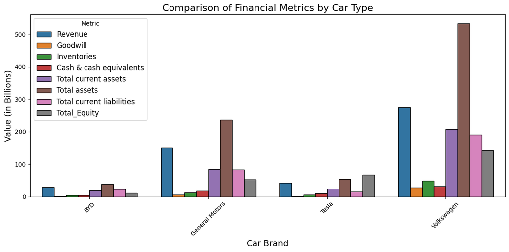

```python
# Get the metrics we'll measure
metrics = ['Revenue', 'Goodwill', 'Inventories', 'Cash & cash equivalents', 'Total current assets', 'Total assets', 'Total current liabilities', 'Total_Equity']
# Melt the data along Car Company and the selected metrics, with the axis names being Metric and Value
df_melted = main_df.melt(id_vars=["Car"], value_vars=metrics, var_name="Metric", value_name="Value")

# Resize the graph from the default size to accomodate the bar plot
plt.figure(figsize=(12, 6))
#
sns.barplot(x="Car", y="Value", hue="Metric", data=df_melted, errorbar=None,edgecolor="black")
plt.title("Comparison of Financial Metrics by Car Type", fontsize=16)
plt.ylabel("Value (in Billions)", fontsize=14)
plt.xlabel("Car Brand", fontsize=14)
plt.xticks(rotation=45)
plt.legend(title="Metric", loc="upper left", fontsize=12)
plt.tight_layout()
#plt.gca().invert_yaxis()
plt.show()
```

**Summary Statistics for Revenue**

Next, we get summary statistics for Revenue, using scipy.stats.describe to report min, max, mean, variance, skewness, and kurtosis of all Revenue data. We also create a boxplot to visualize these statistics.

Then, we form revenue boxplots, broken down by brand and aligned in both directions, to show each carmaker’s revenue distribution: median, IQR, and outliers

```
Summary Statistics of Revenue Overall:
Minimum: 4.046
Maximum: 348.6146028
Mean: 125.01182791477697
Variance: 10899.342714208382
Skewness: 0.48426820080425426
Kurtosis: -1.066059775845485
```

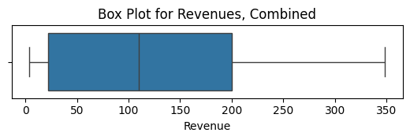

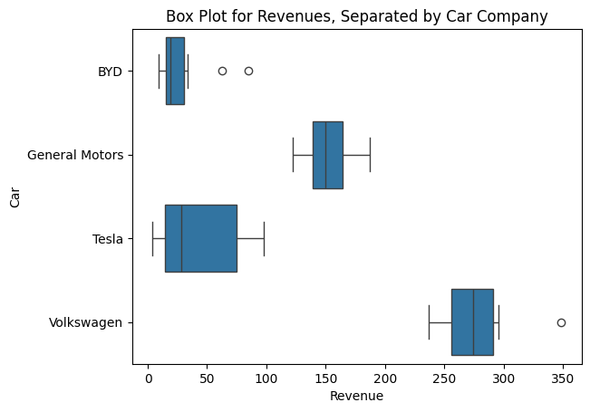

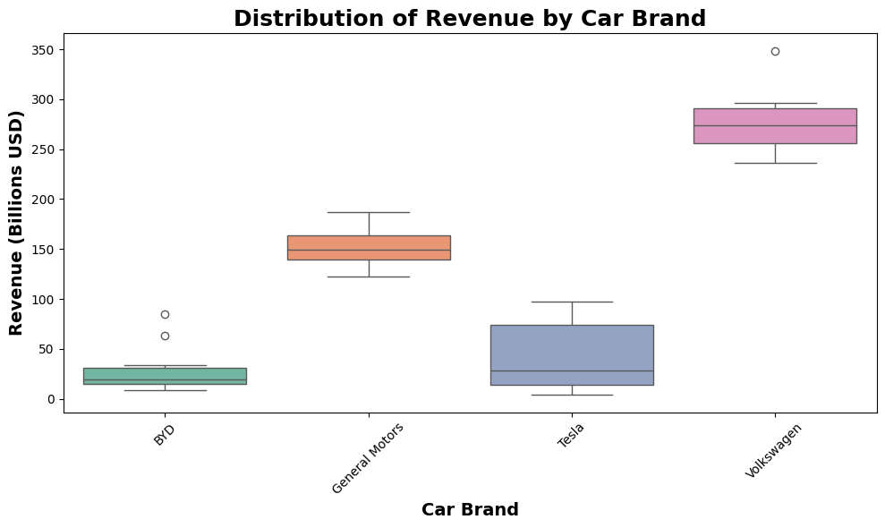

```python
# We use scipy to get summary statistics of Revenue, and print it out
sumstats = scipy.stats.describe(main_df['Revenue'])
print("Summary Statistics of Revenue Overall:")
minr, maxr = sumstats.minmax
print("Minimum: "+str(minr))
print("Maximum: "+str(maxr))
print("Mean: "+str(sumstats.mean))
print("Variance: "+str(sumstats.variance))
print("Skewness: "+str(sumstats.skewness))
print("Kurtosis: "+str(sumstats.kurtosis))
# Resize the graph to be small since we only need it for one boxplot
plt.figure(figsize=(6.4, 1.2))
# We create a boxplot for all revenue data
g1 = sns.boxplot(data=main_df, x="Revenue")
# We set its title
g1.set_title("Box Plot for Revenues, Combined")
# We then display it
plt.show()
# Resize the graph to the default
plt.figure(figsize=(6.4, 4.8))
# We repeat the above, but separate revenue data by car company
g2 = sns.boxplot(data=main_df, x="Revenue", y="Car")
g2.set_title("Box Plot for Revenues, Separated by Car Company")
plt.show()
# Resize the graph
plt.figure(figsize=(10, 6))
# Set up a boxplot for
sns.boxplot(x='Car', y='Revenue', data=main_df, palette='Set2', hue='Car')
# Label the graph
plt.title('Distribution of Revenue by Car Brand', fontsize=18, fontweight='bold')
plt.xlabel('Car Brand', fontsize=14, fontweight='bold')
plt.ylabel('Revenue (Billions USD)', fontsize=14, fontweight='bold')
plt.xticks(rotation=45)
plt.tight_layout()
plt.show()
```

**Rolling Average of Revenue**

To get the rolling average of revenue for each car company, we compute a 3-year moving average of revenue. We do this to smooth out short-term fluctuations. We then overlay the rolling average over the raw data, plotting the semi-transparent raw revenue data line beneath the rolling average to contrast volatility with the underlying trend.

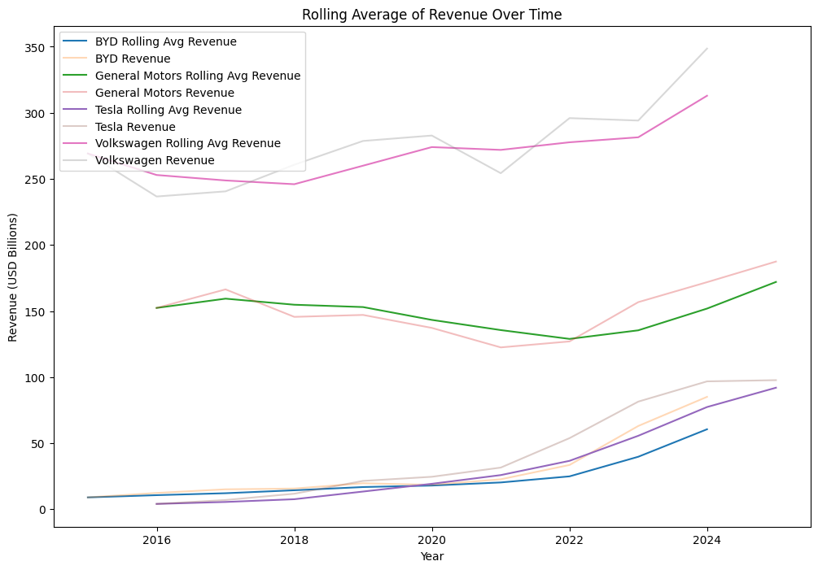

```python
# We set the graph to be larger...
plt.figure(figsize=(12, 8))
# ...in order to plot the averages and rolling averages for each car company
for car in main_df['Car'].unique():
    # Get all the data from the car company we're on, then sort it by date
    car_data = main_df[main_df['Car'] == car].sort_values('Report Date')
    # Get a rolling average of revenue using built-in functions, averaging subsets with a minimum of 1 data point and a maximum of 3
    rolling_avg = car_data['Revenue'].rolling(window=3, min_periods=1).mean()
    # We plot those rolling averages
    plt.plot(car_data['Report Date'], rolling_avg, label=f'{car} Rolling Avg Revenue')
    # We plot the raw revenue data, but with alpha reduced to make it more transparent
    plt.plot(car_data['Report Date'], car_data['Revenue'], label=f'{car} Revenue', alpha = 0.3)

# We format the plot and display it
plt.title('Rolling Average of Revenue Over Time')
plt.xlabel('Year')
plt.ylabel('Revenue (USD Billions)')
plt.legend()
plt.show()
```

**Hypothesis Tests**

We want to see if there is a difference between the liquidities of each company.

Let $\alpha = 0.05$.

Null Hypothesis: There is no difference between the means of liquidity of each car company.

Alternative Hypothesis: There is a difference in the mean of liquidity of at least one car company.

We will perform both ANOVA and Kruskal-Wallis Tests for completeness, using Tukey's and Dunn's Post Hoc Tests, respectively. The main difference is that ANOVA and Tukey's are used when the data meets the conditions for normality, while Kruskal-Wallis and Dunn's are used when they do not.

**ANOVA Test**

```python
# Split dataframe into groups based on car company
grouped_by_car = main_df.groupby('Car')
groupt3 = grouped_by_car['Liquidity']
t3totest = []
for i, t in groupt3:
  t3totest.append(t)

# Perform ANOVA test and display the result
anova_test_liq = scipy.stats.f_oneway(*t3totest)
display(f"P-value: {anova_test_liq.pvalue}")
```

```
'P-value: 0.0015359329837406658'
```

**Conclusion**  
The P-value for the ANOVA test is approximately 0.0015. 0.0015 < 0.05 so we reject the null hypothesis. There is sufficient evidence in favor of the alternative hypothesis. We will proceed to the post hoc test, which for ANOVA is Tukey's HSD Test.

**Tukey's HSD Test**

```python
# Perform Tukey's test and print it
tukey_test_liq = pairwise_tukeyhsd(main_df['Liquidity'], main_df['Car'], alpha=0.05)
print(tukey_test_liq)
```

```
        Multiple Comparison of Means - Tukey HSD, FWER=0.05
===================================================================
    group1         group2     meandiff p-adj   lower  upper  reject
-------------------------------------------------------------------
           BYD General Motors   0.1142 0.7102 -0.1735 0.4019  False
           BYD          Tesla   0.4463  0.001  0.1586 0.7339   True
           BYD     Volkswagen   0.1895 0.3019 -0.0981 0.4772  False
General Motors          Tesla   0.3321 0.0183  0.0444 0.6197   True
General Motors     Volkswagen   0.0753 0.8943 -0.2123  0.363  False
         Tesla     Volkswagen  -0.2567 0.0945 -0.5444 0.0309  False
-------------------------------------------------------------------
```

**Conclusion** The p-value for Tukey's HSD test is less than 0.05 when comparing BYD and Tesla as well as General Motors and Tesla, so we find statistically significant differences and reject the null hypothesis for BYD and Tesla as well as General Motors and Tesla.

**Kruskal-Wallis Test**

```python
# Conduct the Kruskal-Wallis Test and display its results
t3result = scipy.stats.kruskal(*t3totest)
print("H-statistic found by Kruskal-Wallis Test: "+str(t3result.statistic))
print("P-value found by Kruskal-Wallis Test: "+str(t3result.pvalue))
```

```
H-statistic found by Kruskal-Wallis Test: 11.770243902439034
P-value found by Kruskal-Wallis Test: 0.0082131152328583
```

**Dunn's Test**

```python
# Conduct the Dunn's Post-Hoc Test and display its results
t3resultposthoc = posthoc_dunn(main_df, val_col='Liquidity', group_col='Car')
print("Table of p-values found by Dunn's Post Hoc Test:")
display(t3resultposthoc)
```

```
Table of p-values found by Dunn's Post Hoc Test:
```

|  | BYD | General Motors | Tesla | Volkswagen |
| --- | --- | --- | --- | --- |
| BYD | 1.000000 | 0.099981 | 0.001599 | 0.006998 |
| General Motors | 0.099981 | 1.000000 | 0.130774 | 0.292799 |
| Tesla | 0.001599 | 0.130774 | 1.000000 | 0.646195 |
| Volkswagen | 0.006998 | 0.292799 | 0.646195 | 1.000000 |

**Conclusion**

The Dunn's Post Hoc Test finds significant differences when comparing BYD and Tesla, as well as BYD and Volkswagen.

**Frequency Polygon Plot**

We then create a frequency polygon plot to visualize the distribution of the liquidity data.

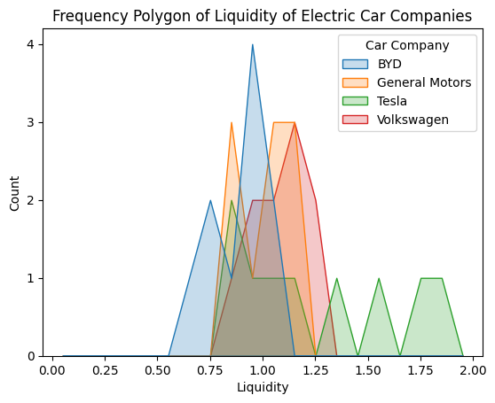

```python
# Create a histogram but display it as a frequency polygon plot
g3 = sns.histplot(data=main_df, x='Liquidity', hue='Car', element='poly', binwidth=0.1, binrange=(0, 2))
# Force the count axis to be only integers
g3.yaxis.set_major_locator(matplotlib.ticker.MaxNLocator(integer=True))
# Label the graph
g3.set_title("Frequency Polygon of Liquidity of Electric Car Companies")
sns.move_legend(g3, "upper right", title='Car Company')
```

**Overall Conclusion**

Both ANOVA and Kruskal-Wallis Tests reject the null hypothesis, however the post hoc tests differ on which companies differ.

Since both post hoc tests find significant differences between BYD and Tesla, we can be confident that differences exist there. Between Tukey's and Dunn's Tests, we prefer Dunn's Test since the data does not meet the conditions for normality, so we also find that there are significant differences between BYD and Volkswagen.

**Liquity and Goodwill Correlations**

Next, we create a correlation plot based on liquidity and goodwill, to see if there is a positive correlation between these two variables. We calculate the Pearson correlation between liquidity and goodwill, then we use .scatterplot to plot the data points for each company.

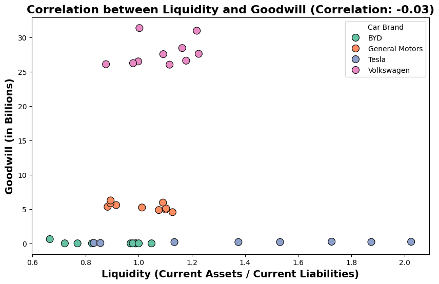

```
Pearson correlation between Liquidity and Goodwill: -0.02813222368866352
```

```python
# We calculate the correlations between liquidity and goodwill - we need only the correlation value in the resulting matrix
correlation = main_df[['Liquidity', 'Goodwill']].corr().iloc[0, 1]
# We resize the graph
plt.figure(figsize=(10, 6))
# We create a scatterplot with liquidity as the x-axis, goodwill as the y-axis, using formatting for readability
sns.scatterplot(x='Liquidity', y='Goodwill', data=main_df, hue='Car', palette='Set2', s=100, edgecolor='black')
# We label the graphs
plt.title(f'Correlation between Liquidity and Goodwill (Correlation: {correlation:.2f})', fontsize=16, fontweight='bold')
plt.xlabel('Liquidity (Current Assets / Current Liabilities)', fontsize=14, fontweight='bold')
plt.ylabel('Goodwill (in Billions)', fontsize=14, fontweight='bold')
plt.legend(title='Car Brand', loc='upper right')
plt.show()

# Print the full correlation value
print(f"Pearson correlation between Liquidity and Goodwill: {correlation}")
```

**Conclusion**

The correlation coefficient of -0.03 indicates a very weak negative correlation between the liquidity of the company and its goodwill. This result was unexpected because, intuitively, the liquidity of a company should have a positive influence on its reputability or goodwill. A company with stronger liquidity would typically be seen as more stable, which could improve its reputation in the market. However, the data does not support this expected relationship, suggesting that other factors may play a more significant role in determining a company's goodwill or reputation than liquidity alone.

# 5. Primary Analysis && 6. Visualization

For the first piece of primary analysis we will use a standard Linear Regression model, using it to compare the reveune to year for each of the electric car companies selected. The goal of our data manipulation is to create a predictive model, specifically one that assists investors in their decision making. By performing this regression, we can follow the slope to see what the revenue is likely to be in the coming years. By pairing this with the analysis of trends in the prior sections, we can form a better picture of the future earnings and directions of the companies, to inform investment decisions. We will perfrom some basic data trasnformatiuons in order to get the data into position for the regression, and then represent each company with a plot of the yearly revenue. The plot will demonstrate the general trend as well as visualize how each data point impacts said trend.

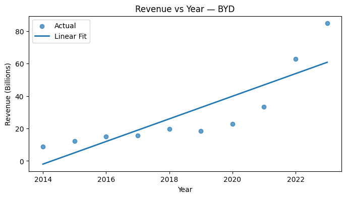

```
BYD → slope : 6.977
```

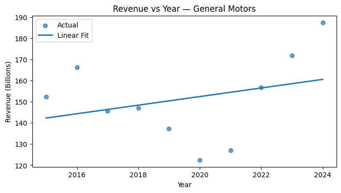

```
General Motors → slope : 2.029
```

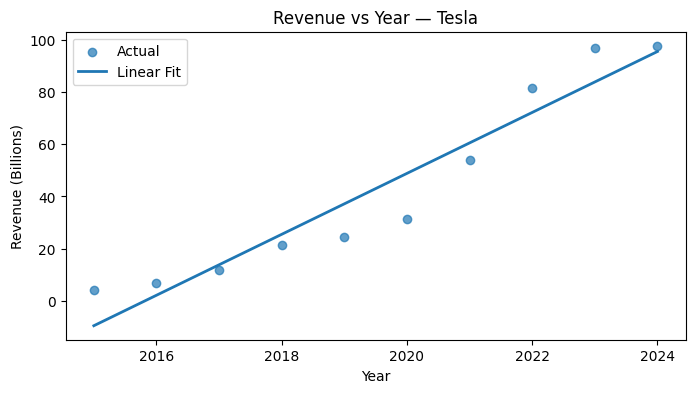

```
Tesla → slope : 11.659
```

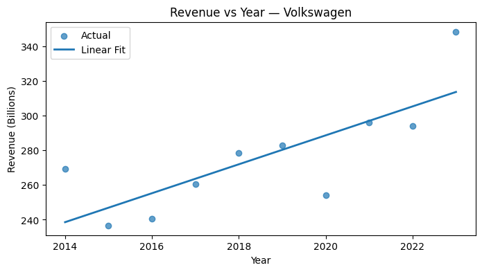

```
Volkswagen → slope : 8.358
```

```python
# Make a copy of the full dataset so we don’t alter the original
df = main_df.copy()

# Ensure our date column is datetime and extract the year as a numeric feature
df["Report Date"] = pd.to_datetime(df["Report Date"])
df["Year"] = df["Report Date"].dt.year

# Convert revenue to float for modeling
df["Revenue"] = df["Revenue"].astype(float)

# List of automakers to analyze
companies = ["BYD", "General Motors", "Tesla", "Volkswagen"]

for company in companies:
    # Filter to one company, drop missing revenue, and sort by year
    sub = (
        df[df["Car"] == company]
        .dropna(subset=["Revenue"])
        .sort_values("Year")
    )
    # Define input (year) and output (revenue)
    X = sub[["Year"]]
    y = sub["Revenue"]

    # Instantiate and fit the linear regression model
    model = LinearRegression()
    model.fit(X, y)

    # Store the fitted values back into the DataFrame
    sub["Predicted"] = model.predict(X)

    # Plot actual revenue as points and the regression line
    plt.figure(figsize=(8, 4))
    plt.scatter(sub["Year"], sub["Revenue"], label="Actual", alpha=0.7)
    plt.plot(sub["Year"], sub["Predicted"], label="Linear Fit", linewidth=2)
    plt.title(f"Revenue vs Year — {company}")
    plt.xlabel("Year")
    plt.ylabel("Revenue (Billions)")
    plt.legend()
    plt.show()

    # Print the model coefficients for interpretation
    print(
        f"{company} → slope : {model.coef_[0]:.3f} "

    )
```

# Analysis of the Visualizations:

1. BYD

`Slope (6.977): On average, BYD’s revenue increased by $6.977 billion each year over this period`

2. General Motors

`Trend: Revenues hover in the $150–160 B range from 2015–2018, dip into the $120–130 B range around 2020, then rebound to about $188 B by 2024`

`Slope (2.029): GM’s average annual revenue gain is modest, around $2.029 billion per year`

3. Tesla

`Trend: Explosive growth from roughly $4 B in 2015 to about $98 B in 2024`

`Slope (11.659): Tesla added on average about $11.659 billion in revenue each year—a faster run‐rate than the others`

4. Volkswagen

`Slope (8.358): VW’s revenues grew by an average of $8.358 billion per year`

Overall Observations:

We can see that the companies are all growing, but the slopes of the regression plots show that Tesla and VW are growing the fastest, withj Tesla standing out as the fastest growing compnay by revenue year over year. We can see that though general motors maintains a high revenue relative to Tesla and BYD, the growth is much slower, indicating that this investment has less short term upside. On the other hand, the lack of volatility for the two larger companies, VW and GM, makes them good options for long term strategy, while BYD and Tesla, with low annual revenues and a lot of room to grow, are more favorable short term investments. By analyzing these plots we can become more informed on the nature of the finances of these comapnies in the context of investment strategy

Key Takeaways:

Slope = average annual change, a steeper slope means faster revenue or income growth per year (or per unit)

Linearity vs. non-linearity: When data accelerates or dips sharply, a linear model struggles to predict the data properly

Best performers: Tesla leads in raw growth but is hardest to pin down with a straight line. VW and BYD offer a blend of strong growth and reliable trends, GM trails both in pace and predictability

**Second Model:**

Once again, to perform analysis we import the necessary packages, in this case, KFold, cross_val_score, and RandomForestRegressor, to evaluate our model's performance. We then transform the data, cleaning the variables we are working with to ensure accuracy. We use two approaches, a linear regression to get a general trend for the data set and a random forest to capture other patterns that may exist within the data. We use cross validation to extract R^2 values to evaulate performance of the models, aiming to see which will more accurately explain the variance in the output. From there we set up and run the two different models, and plot the results to allow for analysis of the trends uncovered. By using two different models we gain multiple perspectives on the relationship between inventories and comprehensive income.

```
Linear Regression R²: -99.539
Random Forest R²: 80.118
```

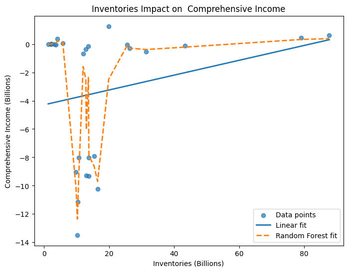

```python
#copy the cleaned balance-sheet DataFrame
df = bs_df.copy()

#ensure our two features are numeric and drop any rows missing either one
df["Inventories"] = pd.to_numeric(df["Inventories"], errors="coerce")
df["Comprehensive_Income"] = pd.to_numeric(df["Comprehensive_Income"], errors="coerce")
df = df.dropna(subset=["Inventories", "Comprehensive_Income"])

#def X and y
X = df[["Inventories"]]
y = df["Comprehensive_Income"]

#set up cross-validation
kf = KFold(n_splits=5, shuffle=True, random_state=42)

#linear Regression: compute R² via CV
lr = LinearRegression()
lr_scores = cross_val_score(lr, X, y, cv=kf, scoring="r2")
lr.fit(X, y)
print(f"Linear Regression R²: {(lr_scores).mean():.3f}")

#random Forestfor a nonlinear ensemble model
rf = RandomForestRegressor(n_estimators=100, random_state=42)
rf_scores = cross_val_score(rf, X, y, cv=kf, scoring="r2")
rf.fit(X, y)
print(f"Random Forest R²: {np.abs(rf_scores).mean():.3f}")

#visualize the linear fit against the raw data
plt.figure(figsize=(8,6))
plt.scatter(X, y, alpha=0.7, label="Data points")
# sort for clean lines
idx = X.values.flatten().argsort()
xs = X.values.flatten()[idx]

# plot linear fit
plt.plot(xs,
         lr.predict(X).flatten()[idx],
         linewidth=2,
         label="Linear fit")

# plot random forest fit
plt.plot(xs,
         rf.predict(X).flatten()[idx],
         linestyle="--",
         linewidth=2,
         label="Random Forest fit")

plt.xlabel("Inventories (Billions)")
plt.ylabel("Comprehensive Income (Billions)")
plt.title("Inventories Impact on  Comprehensive Income")
plt.legend()
plt.show()
```

**Takeaways:**

Linear Regression: R² ≈ –99.54

This is a poor fit. At certain points, the squared errors are almost 100 times larger than the variance of the data.

**Why is Linear Regression so bad?**

Outliers blow up the squared error.

The actual relationship may be strongly non-linear or influenced by other missing factors.

Small sample size → one or two extreme points dominate the error.

**Next Model:**

It's still not great, but better than the straight line. The forest can bend around a couple of the large negative income points, reducing error.

What it tells you: There is structure beyond a straight line but the flexible tree ensemble can’t generalize effectively.

**Overall:**

The failure of both models indicates a lack of relationship here between the inventory and the income, meaning when taking this data as a guidline for investment that a savvy investor (such as someone using this tutorial) would not use inventory as a marker to determine where their investment goes, as it does not correlate to the success of the company.

# 7. Insights and Conclusions

This process can be used to observe trends within a market, and reveal the successes and failures between competitors, as well as be used to predict the future position of companies to inform investment decisions. Someone, after following this tutorial, should be equipped not only to make evaulations on the data here but have the ability to extrapolate these skills to analyze other investment opportunities and place themslves in an adventageous position when selecting what investment opportunities to pursue. As machine learning continues to evolve, understanding the data science process behind its development and implementation in real-world scenarios will be crucial in navigating through the coming future.